# Predicting Flight Delays at the Pittsburgh Airport

Group 21: Prem Loganathan, Jeff Scanlon, Jingfang Yuan

5/14/2020

# Welcome and Introduction

Hello and welcome to our Data Mining Project! Thank you for taking the time to read about our methodology and findings.

This document will be organized in the following way:

1. Statement of Problem and Objective
2. Cleaning the Data
3. Exploratory Dat Analysis
4. Fitting our Models
   - Feature selection
   - Regression models
   - Tree-based models
   - Measures of fit
5. Comparison to 2006 Data
6. Findings
7. Conclusion

## 1. Statement of Problem and Objective

Delayed flights can be quite a nuisance. For passengers, delays can be costly. Costs associated with flight delays range from the cost of missed connections (flights that leave without you), the opportunity cost of being “trapped” in a airport terminal for more time than anticipated, and the social, mental, emotional, and physical toll that extended travel times can cause. Delayed flights can also be costly for airlines, who sometimes have to bear some of the financial burdens of delays, which may include compensating customers for delays that were ultimately diverted or cancelled, or providing hotel vouchers for flights that have been delayed until the next day.

Our objective in this project is to mine data from a full year of flights that have arrived in and departed from the Pittsburgh, Pennsylvania airport. There were over 100,000 flights into and out of the Pittsburgh airport during the year 2019. Using different data mining methods, we will explore this data and look for variables that might be helpful in predicting which flights are likely to be delay, and by how long. Wouldn’t it be helpful to have a tool that helped you predict which flights are likely to be delayed while you are comparison shopping online to find which flights are right for you? If you knew, weeks or months ahead of time, whether or not a flight was likely to leave on time? We will not be developing that tool here, but we will be trying to identify any variables that could be used as predictors if and when such a tool is developed.

Thank you for reading our Problem Statement. Now, onto Cleaning the Data!

## 2. Cleaning the Data

#### Data Dictionary:

Here we will provide a description of some of the variables that may not be self-explanatory or may have confusing names. + “Carrier” refers to the airline responsible for the flight. + “CrsArrTime” and “CrsDepTime” refer to the scheduled arrival and departure times of the flight, while “ArrTime” and “DepTime” refer to the actual arrival and departure times. + “ArrDelayNew” is the difference between CrsArrTime and ArrTime in minutes. If the difference is negative (an early flight), it is coded as 0. A positive value means the flight was late by that number of minutes. + “DepDelayNew” is the same as ArrDelayNew, but for departure delays instead of arrival delays. + We also created some of our own variables, like “AdjArrTime” and “AdjDepTime,” which add 24 hours (one day) to the ArrTime and DepTime, respectively, if the flight was delayed until the next day. + We created “ArrTimeGroup” and “DepTimeGroup,” which are factors that classify arrival and departure times as Early Morning, Morning, Afternoon, Evening, Night, and Late Night. + “Distance” refers to the miles between Origin and Destination airports.

#### Reading in the Data

Next, we will read in our data file from an excel document and remove certain redundant variables.

```r
PIT_2019_raw <- read_excel("PIT_2019.xlsx")
#View(PIT_2019_raw)
#names(PIT_2019_raw)
#summary(PIT_2019_raw)

# Remove columns which have all fields as NAs and unrelevant columns
PIT_2019_1 <- select(PIT_2019_raw,-c(Year, Div1WheelsOn,Div1AirportSeqID, Div1AirportID,Div1Airport,DivDistance,DivArrDelay,DivActualTimeElapsed,DivReachedDest, DivAirportLandings, Flights,FirstDeptTime, TotalAddGTime, LongestAddGTime))
```

#### Converting variables to factors

Next, we convert many of our variables into factors.

```r
#Convert to factors
PIT_2019_2 <- PIT_2019_1
PIT_2019_2$Quarter <- as.factor(PIT_2019_2$Quarter)
levels(PIT_2019_2$Quarter) <-c("First", "Second", "Third", "Fourth");

PIT_2019_2$Month <- as.factor(PIT_2019_2$Month)
levels(PIT_2019_2$Month) <- c("Jan", "Feb", "Mar", "Apr", "May", "June", "July", "Aug", "Sep", "Oct", "Nov", "Dec");

PIT_2019_2$DayOfWeek <- as.factor(PIT_2019_2$DayOfWeek)
levels(PIT_2019_2$DayOfWeek) <- c("Mon", "Tues", "Wed", "Thur", "Fri", "Sat", "Sun");

PIT_2019_2$Carrier <- as.factor(PIT_2019_2$Carrier)
levels(PIT_2019_2$Carrier) <- c("Endeavor", "American", "Alaska", "JetBlue", "Delta", "ExpressJet", "Frontier", "Allegiant", "Hawaiian", "Envoy", "Spirit", "PSA", "SkyWest", "United", "Southwest", "Mesa", "Republic");

#PIT_2019_2$Year <- as.factor(PIT_2019_2$Year)
PIT_2019_2$DayOfMonth <- as.factor(PIT_2019_2$DayOfMonth)
PIT_2019_2$DayOfWeek <- as.factor(PIT_2019_2$DayOfWeek)
PIT_2019_2$UniqueCarrier <- as.factor(PIT_2019_2$UniqueCarrier)
PIT_2019_2$CarrierID <- as.factor(PIT_2019_2$CarrierID)
PIT_2019_2$Carrier <- as.factor(PIT_2019_2$Carrier)
PIT_2019_2$TailNum <- as.factor(PIT_2019_2$TailNum)
PIT_2019_2$FlightNum <- as.factor(PIT_2019_2$FlightNum)
PIT_2019_2$OriginID <- as.factor(PIT_2019_2$OriginID)
PIT_2019_2$OriginSeqID <- as.factor(PIT_2019_2$OriginSeqID)
PIT_2019_2$OriginCityID <- as.factor(PIT_2019_2$OriginCityID)
PIT_2019_2$Origin <- as.factor(PIT_2019_2$Origin)
PIT_2019_2$OriginCity <- as.factor(PIT_2019_2$OriginCity)
PIT_2019_2$OriginStAbbr <- as.factor(PIT_2019_2$OriginStAbbr)
PIT_2019_2$OriginState <- as.factor(PIT_2019_2$OriginState)
PIT_2019_2$OriginStateFips <- as.factor(PIT_2019_2$OriginStateFips)
PIT_2019_2$OriginWac <- as.factor(PIT_2019_2$OriginWac)
PIT_2019_2$DestID <- as.factor(PIT_2019_2$DestID)
PIT_2019_2$DestSeqID <- as.factor(PIT_2019_2$DestSeqID)
PIT_2019_2$DestCityID <- as.factor(PIT_2019_2$DestCityID)
PIT_2019_2$Dest <- as.factor(PIT_2019_2$Dest)
PIT_2019_2$DestCity <- as.factor(PIT_2019_2$DestCity)
PIT_2019_2$DestStateAbbr <- as.factor(PIT_2019_2$DestStateAbbr)
PIT_2019_2$DestStateFips <- as.factor(PIT_2019_2$DestStateFips)
PIT_2019_2$DestState <- as.factor(PIT_2019_2$DestState)
PIT_2019_2$DestWac <- as.factor(PIT_2019_2$DestWac)
PIT_2019_2$CancellationCode <- as.factor(PIT_2019_2$CancellationCode)
PIT_2019_2$Diverted <- as.factor(PIT_2019_2$Diverted)
PIT_2019_2$DistanceGroup <- as.factor(PIT_2019_2$DistanceGroup)
```

#### Creating New Variables

Next, we created new variables called “AdjArrTime”, “AdjDepTime”, “ArrTimeGroup”, and “DepTimeGroup,” which will account for delays that push the arrival or departure time to the next day. We also created “ArrDelayNewLog” to make a log transformation of the Arrival Delay data to see if we could normalize the distribution.

```r
#Create Adjusted Arrival and Departure Times (Earlier than 5:00am)
PIT_2019_2 <- mutate(PIT_2019_2, AdjArrTime = ifelse(ArrTime %in% 0:500, ArrTime+2400, ifelse(CrsArrTime - ArrTime > 200, ArrTime+2400, ArrTime)))

PIT_2019_2 <- mutate(PIT_2019_2, AdjDepTime = ifelse(DepTime %in% 0:500, DepTime+2400, ifelse(CrsDepTime - DepTime > 200, DepTime+2400, DepTime)))
#ifelse(CrsArrTime %in%2000:2400 & DepTime %in%500:1600, DepTime+2400, ArrTime)))


#Create Arrival and Depature Time Factors
PIT_2019_2$ArrTimeGroup[PIT_2019_2$ArrTime >=500 & PIT_2019_2$ArrTime <900] <- "Early Morning"
PIT_2019_2$ArrTimeGroup[PIT_2019_2$ArrTime >=900 & PIT_2019_2$ArrTime <1300] <- "Morning"
PIT_2019_2$ArrTimeGroup[PIT_2019_2$ArrTime >=1300 & PIT_2019_2$ArrTime <1700] <- "Afternoon"
PIT_2019_2$ArrTimeGroup[PIT_2019_2$ArrTime >=1700 & PIT_2019_2$ArrTime <2100] <- "Evening"
PIT_2019_2$ArrTimeGroup[PIT_2019_2$ArrTime >=2100 & PIT_2019_2$ArrTime <2500] <- "Night"
PIT_2019_2$ArrTimeGroup[PIT_2019_2$ArrTime >=00 & PIT_2019_2$ArrTime <100] <- "Night"
PIT_2019_2$ArrTimeGroup[PIT_2019_2$ArrTime >=100 & PIT_2019_2$ArrTime <500] <- "Late Night"

PIT_2019_2$DepTimeGroup[PIT_2019_2$DepTime >=500 & PIT_2019_2$DepTime <900] <- "Early Morning"
PIT_2019_2$DepTimeGroup[PIT_2019_2$DepTime >=900 & PIT_2019_2$DepTime <1300] <- "Morning"
PIT_2019_2$DepTimeGroup[PIT_2019_2$DepTime >=1300 & PIT_2019_2$DepTime <1700] <- "Afternoon"
PIT_2019_2$DepTimeGroup[PIT_2019_2$DepTime >=1700 & PIT_2019_2$DepTime <2100] <- "Evening"
PIT_2019_2$DepTimeGroup[PIT_2019_2$DepTime >=2100 & PIT_2019_2$DepTime <2500] <- "Night"
PIT_2019_2$DepTimeGroup[PIT_2019_2$DepTime >=00 & PIT_2019_2$DepTime <100] <- "Night"
PIT_2019_2$DepTimeGroup[PIT_2019_2$DepTime >=100 & PIT_2019_2$DepTime <500] <- "Late Night"

PIT_2019_2$ArrTimeGroup <- as.factor(PIT_2019_2$ArrTimeGroup)
PIT_2019_2$DepTimeGroup <- as.factor(PIT_2019_2$DepTimeGroup)

PIT_2019_2 <- mutate(PIT_2019_2,
                     ArrTimeGroup = recode_factor(ArrTimeGroup,
                              `1` = "Early Morning",
                              `2` = "Morning",
                              `3` = "Afternoon",
                              `4` = "Evening",
                              `5` = "Night",
                              `6` = "Late Night",),
                     DepTimeGroup = recode_factor(DepTimeGroup,
                              `1` = "Early Morning",
                              `2` = "Morning",
                              `3` = "Afternoon",
                              `4` = "Evening",
                              `5` = "Night",
                              `6` = "Late Night"
                                                  ))
```

#### Handling missing values

The variable ArrDelayNew will be used as an outcome variable in our analysis. Therefore, we need to remove any observations from our data set where this variable is NULL. This will only remove 1,980 observations from the dataset, still leaving us with 98,820 observations to analyze.

```r
#Remove NA for outcome variable ArrDelayNew
PIT_2019_3 <- PIT_2019_2[!is.na(PIT_2019_2$ArrDelayNew), ]

#After removing NAs for outcome variable, cancellation and divertion records are also removed. Hence we remove those columns also fron analysis

PIT_2019_3 <- select(PIT_2019_3,-c(Cancelled, CancellationCode, Diverted))
#summary(PIT_2019_3)

#Removing single records which cause CV error due to absence in test or train data
PIT_2019_3 <- PIT_2019_3[!(PIT_2019_3$OriginCity=="San Diego, CA"),]
PIT_2019_3 <- PIT_2019_3[!(PIT_2019_3$OriginCity=="San Juan, PR"),]
```

#### Correlation Matrices

Next, we will create correlation matrices to determine which variables are highly correlated with each other. This will allow us to exclude certain redundant variables from our model that would otherwise impede our interpretation. We have built multiple correlation matrices to try to identify the relationship between different variables. The correlation matrices are shown below.

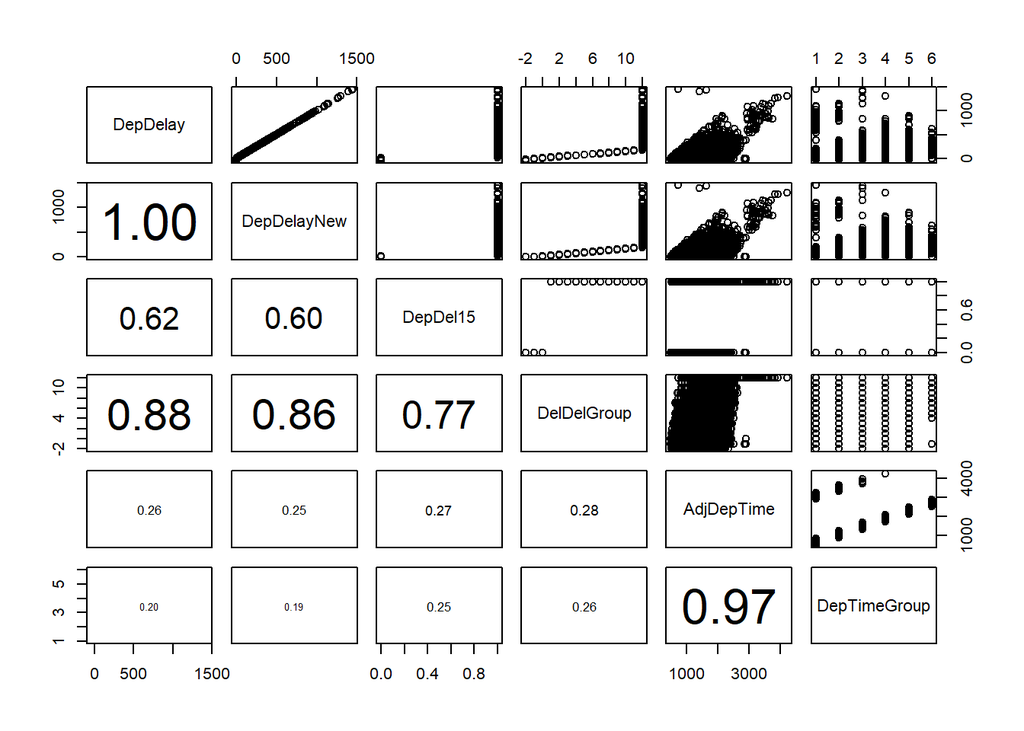

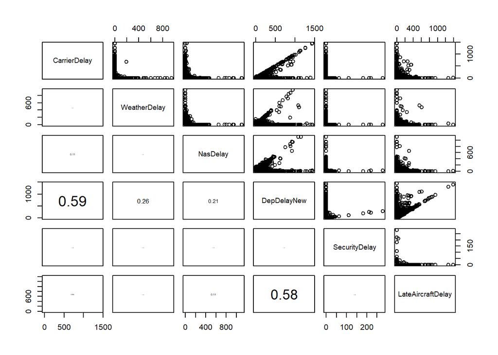

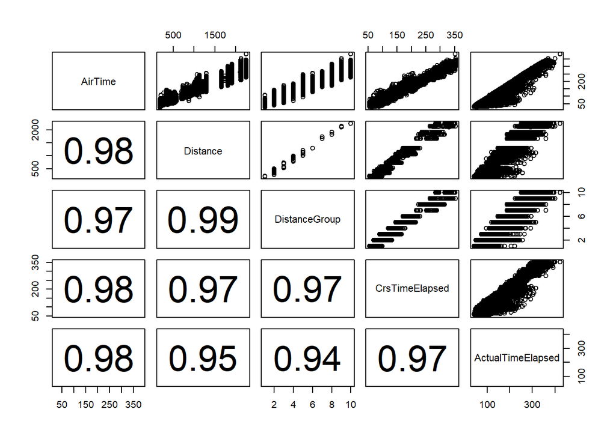

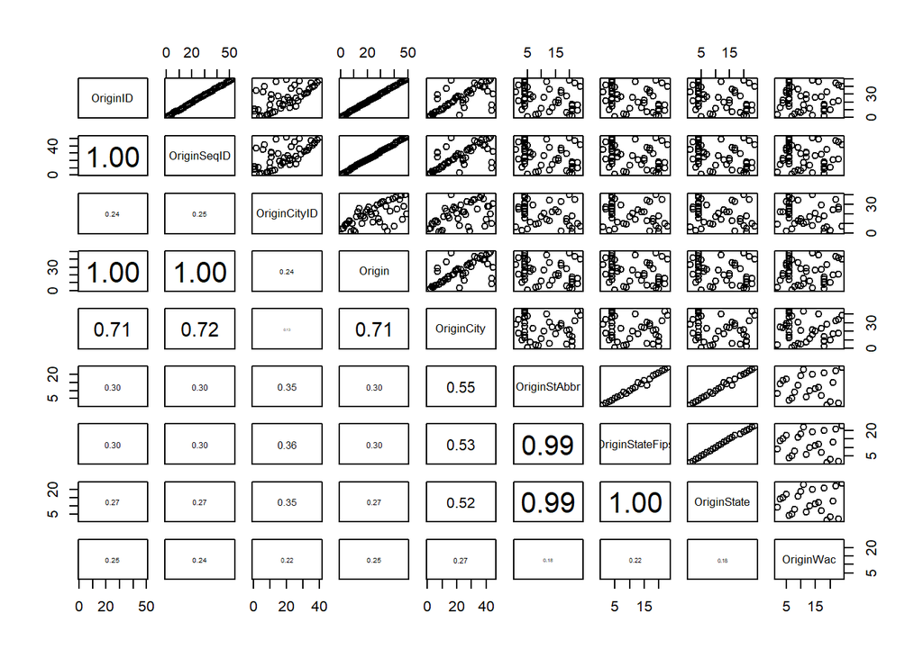

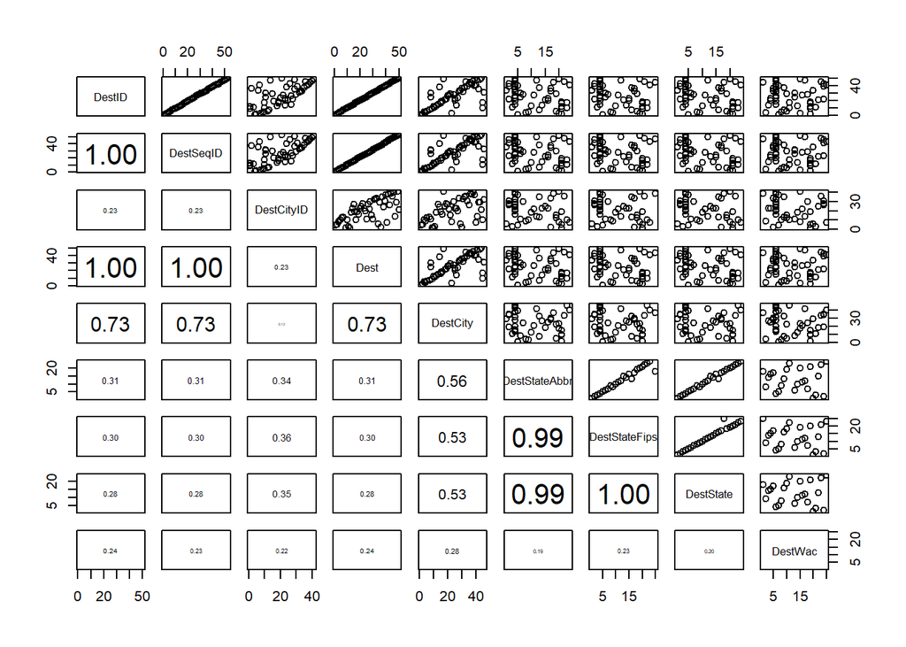

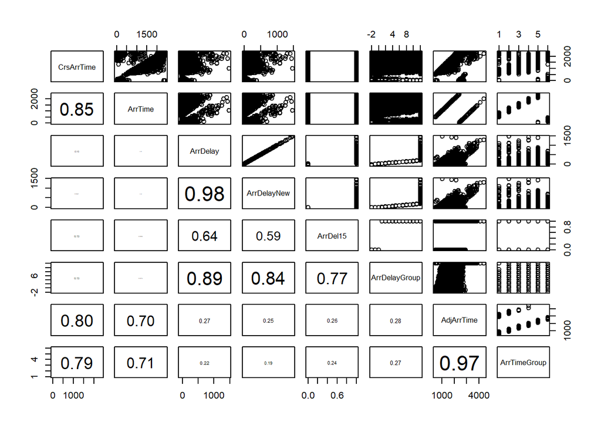

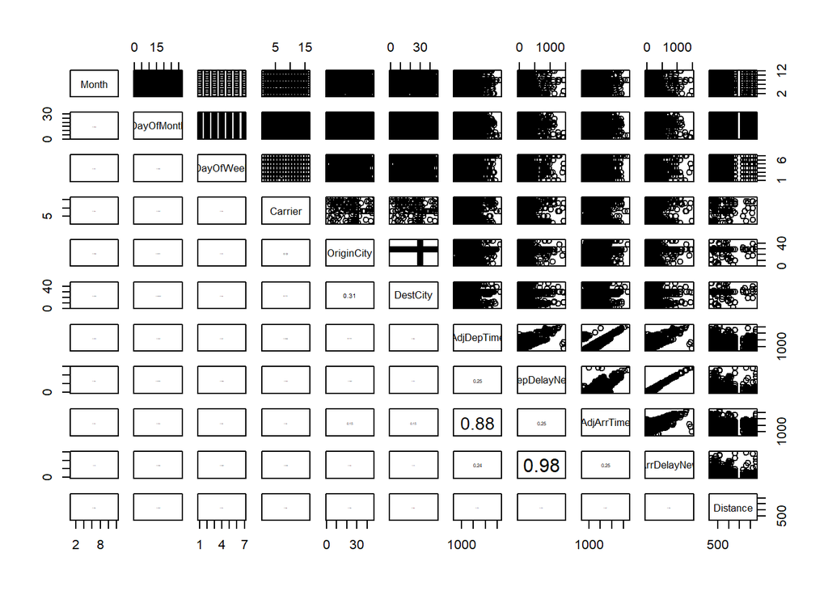

```r
#Final selected variables
pairs(PIT_2019_3[, c("Month", "DayOfMonth","DayOfWeek", "Carrier","OriginCity", "DestCity", "AdjDepTime" ,"DepDelayNew", "AdjArrTime", "ArrDelayNew" ,"Distance" )],
      lower.panel = panel.cor)
```

```r
#Quarter and Month are highly correlated. Quarter will be removed from analysis. ArrDelayNew and DepDelayNew are also highly correlated. So in analysis for arrial delay, departure delay will not be used and vice versa.
```

#### Excluding Variables

**Correlated variables**

The matrices above show that some variables have strong correlations (>0.7) with each other (like DepDelay, DepDelayNew, DepDel15, DelDelGroup). While DepDelay column has departure delay data with negative values for early departure, DepDelayNew column coverts all early departures to 0 as the consideration here is about the delays only. Hence DepDelayNew column will be considered. The same is true for variables related to arrival delays. For arrival delay, ArrDelayNew column will be considered.

**Variables not available before the event of delay**

It was observed that the arrival delay is highly correlated with the departure delay. So, if a flight is delayed during departure, there is high chances for the arrival also to be delayed. But the departure delay wont be available in advance for us to make a good prediction. Similarly delay information like “CarrierDelay”, “WeatherDelay”, “NasDelay”, “SecurityDelay”, “LateAircraftDelay” add up to Departure and Arrival delay. Adding these variables in the model will fit the past data well. But it wont help in predicting the future delay as we wont know if these delay will happen for the flights.

Due to the correlation, we have reduced our dataset to include only the following variables:

Month, DayOfMonth, DayOfWeek, Carrier,OriginCity, DestCity, DepDelayNew, ArrDelayNew ,Distance, ArrTimeGroup, DepTimeGroup, AdjDepTime, AdjArrTime, CarrierDelay, WeatherDelay, NasDelay, SecurityDelay, LateAircraftDelay.

```r
# Variables selected for analysis
PIT_2019_final <- PIT_2019_3[c("Month", "DayOfMonth","DayOfWeek", "Carrier","OriginCity", "DestCity", "DepDelayNew", "ArrDelayNew" ,"Distance", "ArrTimeGroup", "DepTimeGroup", "AdjDepTime", "AdjArrTime", "CarrierDelay", "WeatherDelay", "NasDelay", "SecurityDelay", "LateAircraftDelay")]
```

#### Division of Datasets

The final step of our cleaning process is to divde the dataset into two: One dataset corresponding to arrivals in the Pittsburgh airport and another dataset corresponding to departures from the Pittsburgh airport. This disaggregation is necessary so that our analyses only take into account the relevant data.

These datasets will be called “PIT_2019_ArrivePit” and “PIT_2019_DepartPit”, respectively. The majority of this report will focus on Arrival Delays.

## 3. Exploratory Data Analysis

In this section of the report, we produce various visualizations to help us gain a better understanding of the data. Primarily, we will look at different distributions of the data as well as plots that show us the relationship between two or three different variables. The purpose of these visualizations is to help us narrow our focus even further for when will start fitting models to the data.

#### Violin Plots and Box Plots

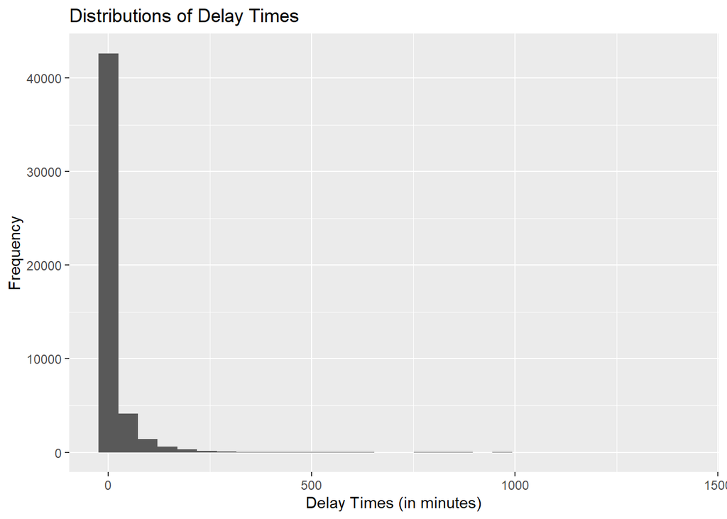

```r
#Arrival Delay by Month
ggplot(PIT_2019_ArrivePit.df, aes(x=ArrDelayNew)) + geom_histogram() + labs(title="Distributions of Delay Times", x="Delay Times (in minutes)", y="Frequency") + theme(legend.position="none")
```

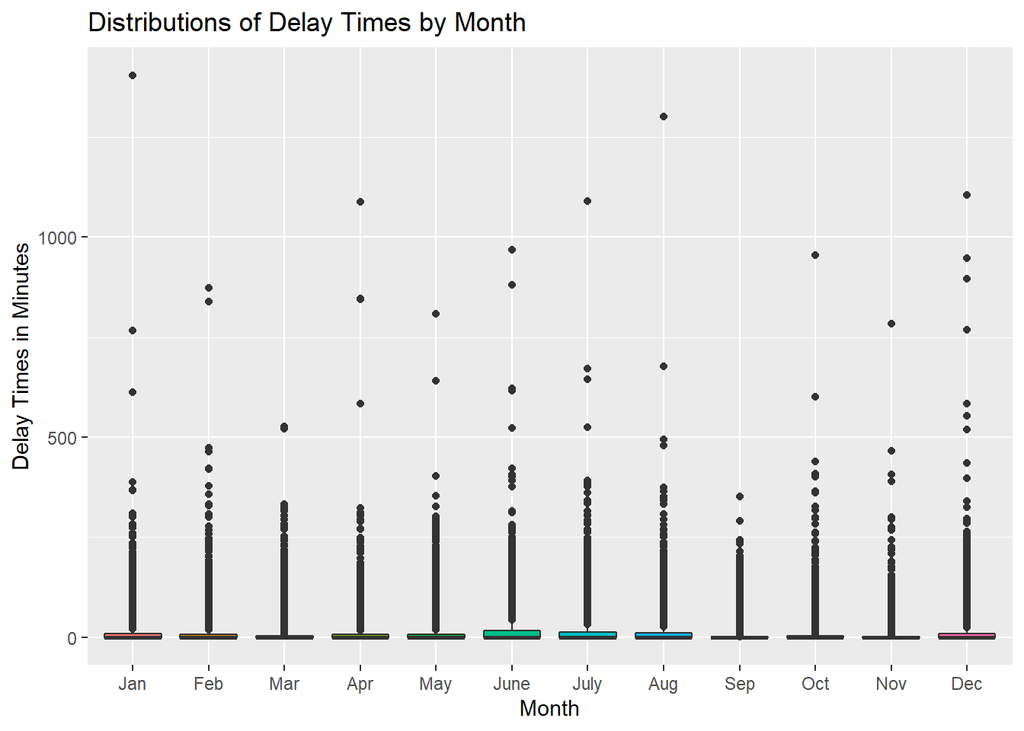

```r
ggplot(PIT_2019_ArrivePit.df, aes(x=Month, y=ArrDelayNew, fill=Month)) + geom_boxplot() + labs(title="Distributions of Delay Times by Month", x="Month", y="Delay Times in Minutes", fill= "Month") + theme(legend.position="none")
```

**Interpretation:**

The histogram above indicates that the distribution of our data is not normal. It is highly skewed to the right. Many of the observations have a delay time = 0, but there are also flights that have large delay times (of 1000 minutes or more), though these do not appear on the histogram because there are much fewer of them.

The boxplots also show this skew, because most of the data is contained in the small boxes located at the bottom of the plot.

Below, we will look at the distribution of the data only when considering flights that had any delay whatsoever (arrival delay > 0). If there is no delay, these flights will be excluded from the plots. This should result in slightly better looking plots.

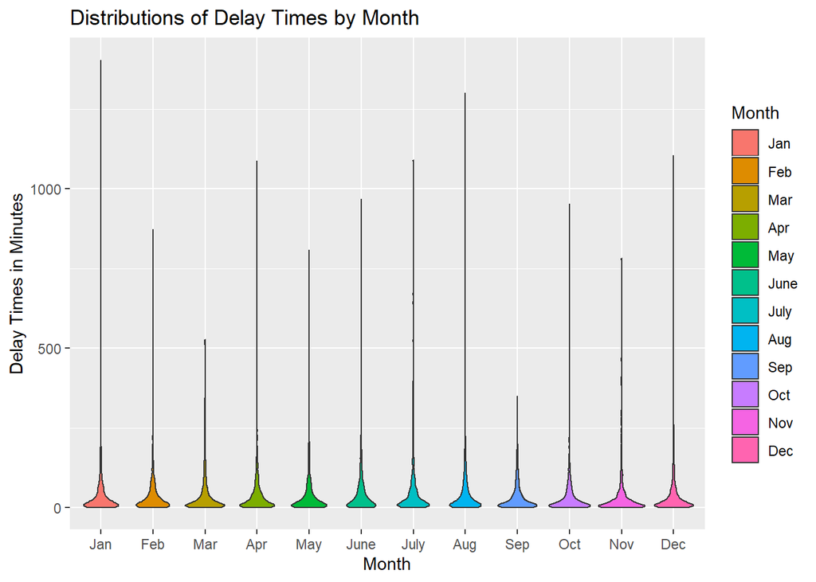

```r
greater0 <- subset(PIT_2019_ArrivePit.df, ArrDelayNew > 0)

#Arrival Delay by Month
ggplot(greater0, aes(x=Month, y=ArrDelayNew, fill=Month)) + geom_violin() + labs(title="Distributions of Delay Times by Month", x="Month", y="Delay Times in Minutes", fill= "Month")
```

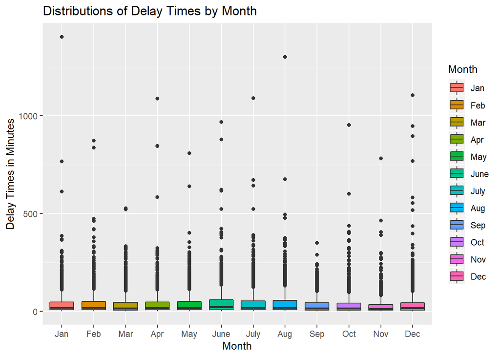

```r
ggplot(greater0, aes(x=Month, y=ArrDelayNew, fill=Month)) + geom_boxplot() + labs(title="Distributions of Delay Times by Month", x="Month", y="Delay Times in Minutes", fill= "Month")
```

**Interpretation:**

The plots do look somewhat better, but they are still not ideal for giving us a good picture of the distribution. This is again because the actual spread of the data is still so large compared to the range in which *most* of the data is located. We can resolve this by zooming in once more to a smaller range of the data.

**This time, we will look only at flights that were delayed by > 0 minutes, but < = 60 minutes**

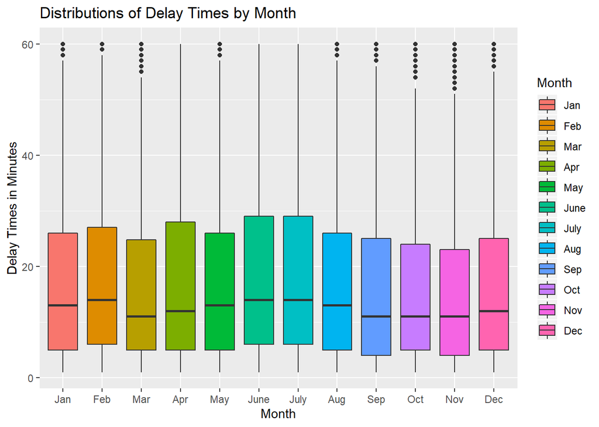

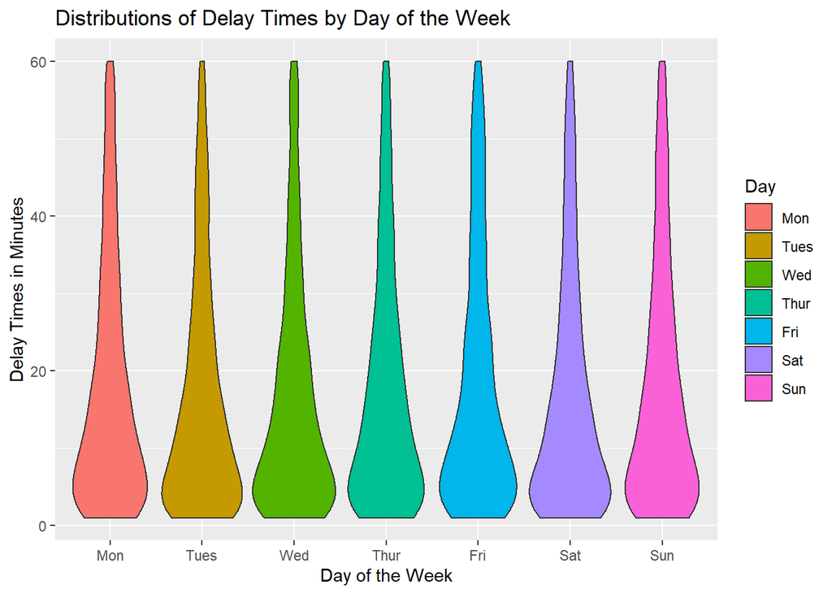

**Interpretation:**

The boxplot and violin plot above are useful for visualizing the distribution of delay times across different categories (Day of the Week and Month). The violin plot for Day of the Week shows that the distribution of delay times are very similar across the different days. Therefore, we might not expect this feature to have much predictive power. The boxplot for Month shows slight variations in delay times. For example, June and July appear to have slightly larger medians, while March and September seem to have slightly smaller medians. There are also slight differences in occurences that are deemed outliers, represented as dots on the top of the plot.

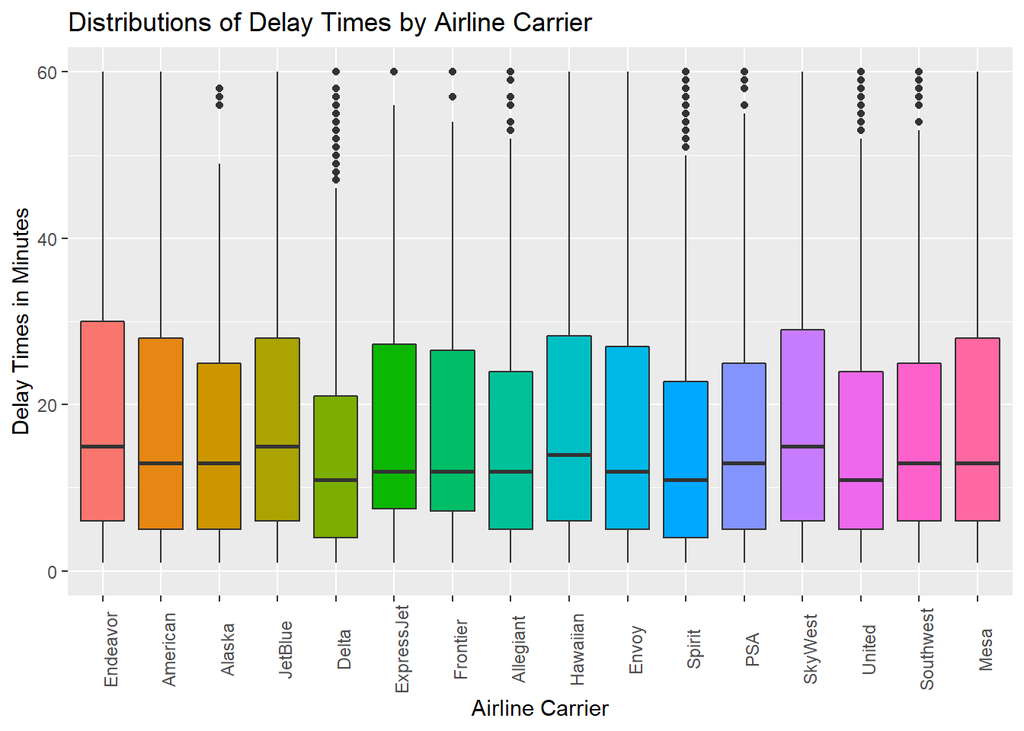

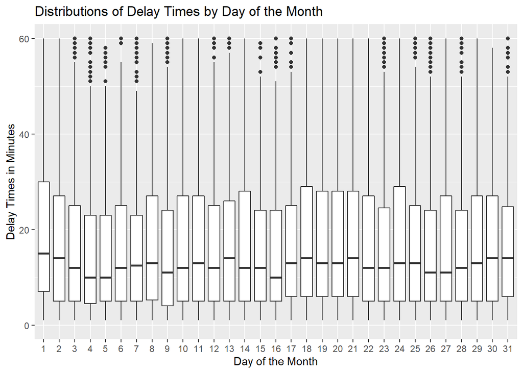

**Interpretation:**

These boxplots show perhaps slightly more variation in the distributions than the previous categories. From these visualizations we might expect Carrier or Day of the Month to have signficance in models that we fit. The differences do not appear so profound to suggest that these features would have a large impact on the outcome variable.

**Next, we will expand the range to look at delays that are > 0 minutes but <= 120 minutes.**

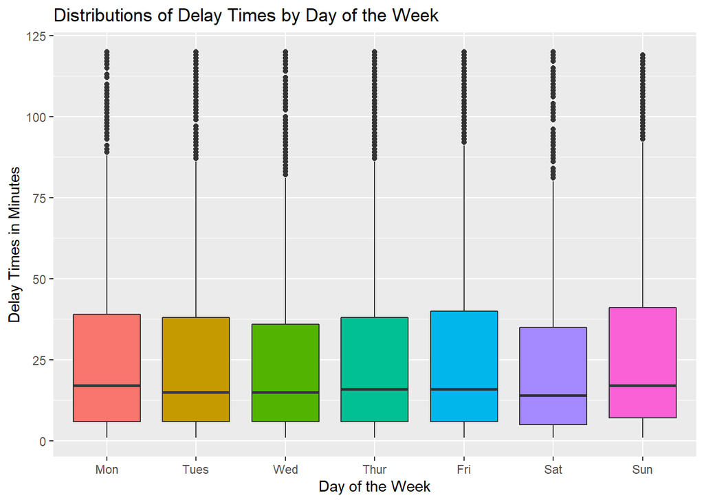

```r
#Arrival Delay by Carrier
greater60 <- subset(PIT_2019_ArrivePit.df, ArrDelayNew > 0 & ArrDelayNew <= 120)

ggplot(greater60, aes(x=DayOfWeek, y=ArrDelayNew, fill=DayOfWeek)) + geom_boxplot() + labs(title="Distributions of Delay Times by Day of the Week", x="Day of the Week", y="Delay Times in Minutes", fill= "Day") + theme(legend.position="none")
```

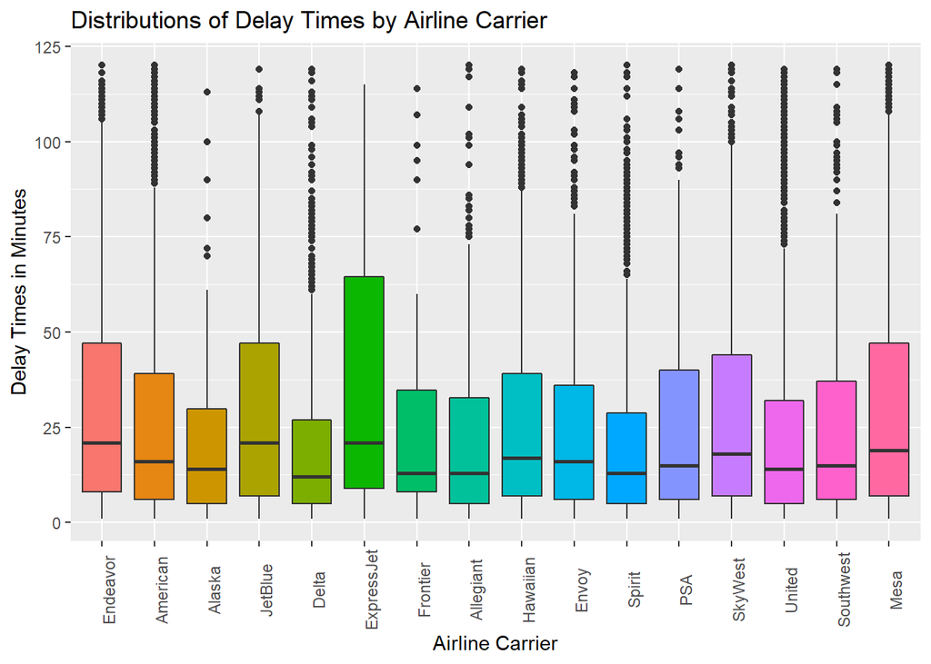

```r
ggplot(greater60, aes(x=Carrier, y=ArrDelayNew, fill=Carrier)) + geom_boxplot() + labs(title="Distributions of Delay Times by Airline Carrier", x="Airline Carrier", y="Delay Times in Minutes", fill= "Airline Carrier") + theme(legend.position="none", axis.text.x=element_text(angle=90))
```

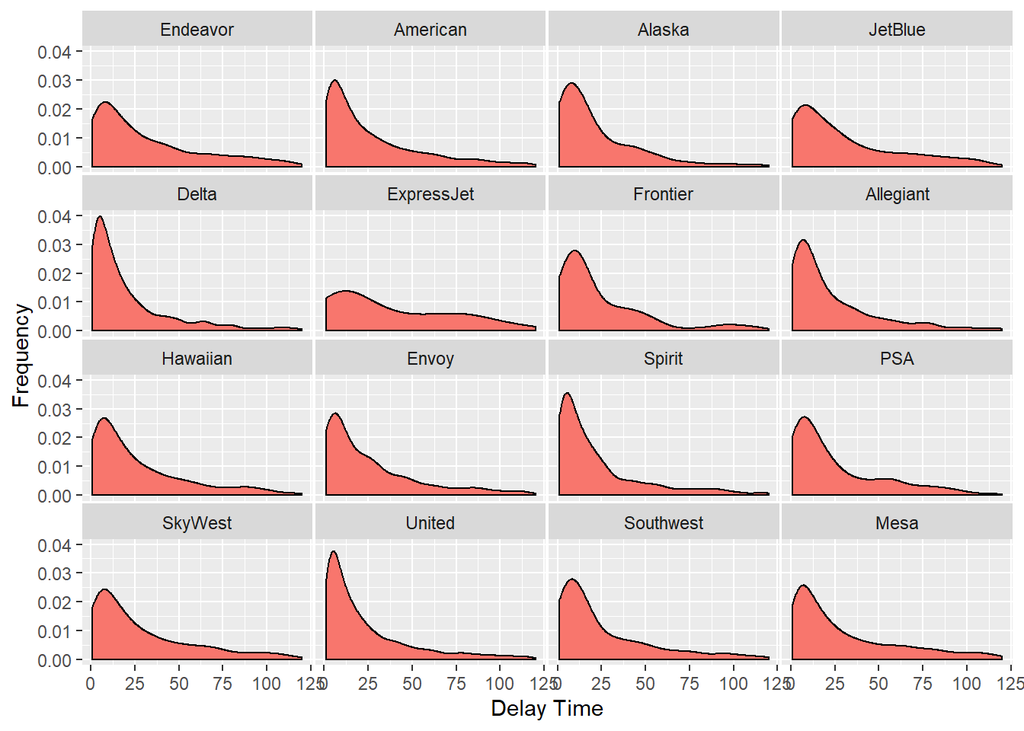

```r
car2 <- subset(PIT_2019_ArrivePit.df , ArrDelayNew>0 & ArrDelayNew<=120)
ggplot(car2, aes(x=ArrDelayNew, fill="Steelblue")) + geom_density(binwidth=15) + facet_wrap(~Carrier) + theme(legend.position="none", panel.spacing=unit(0.1, "lines")) + labs(x="Delay Time", y="Frequency")
```

**Interpretation:**

When we continue to take a closer look at the distributions for Day of the Week, we continue to see very few differences. This will likely be a feature that will not be significant in our models.

#### Scatterplots

We also produced simple scatterplot distributions for arrival delays and departure delays by carrier, as shown below.

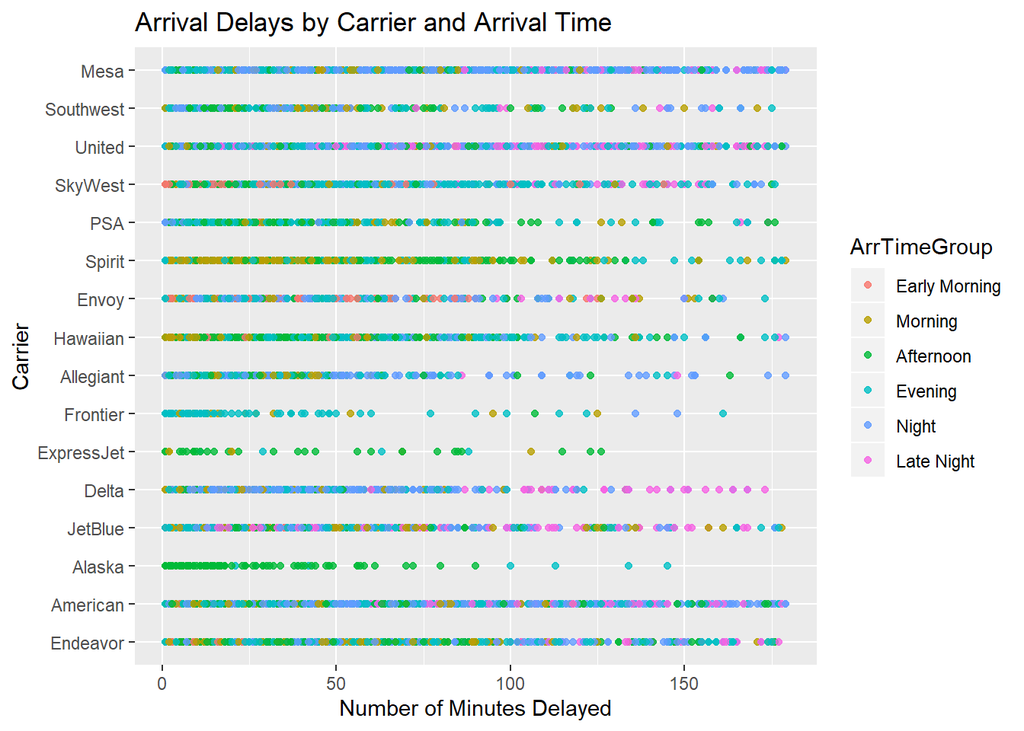

```r
less120a <- subset(PIT_2019_ArrivePit.df, ArrDelayNew > 0 & ArrDelayNew < 180)
less120d <- subset(PIT_2019_DepartPit.df, DepDelayNew > 0 & DepDelayNew < 180)

ggplot(data=less120a, aes(x=ArrDelayNew, y=Carrier, color=ArrTimeGroup)) + geom_point(alpha=0.8) + labs(x="Number of Minutes Delayed", fill="Scheduled Arrival Time", title="Arrival Delays by Carrier and Arrival Time")
```

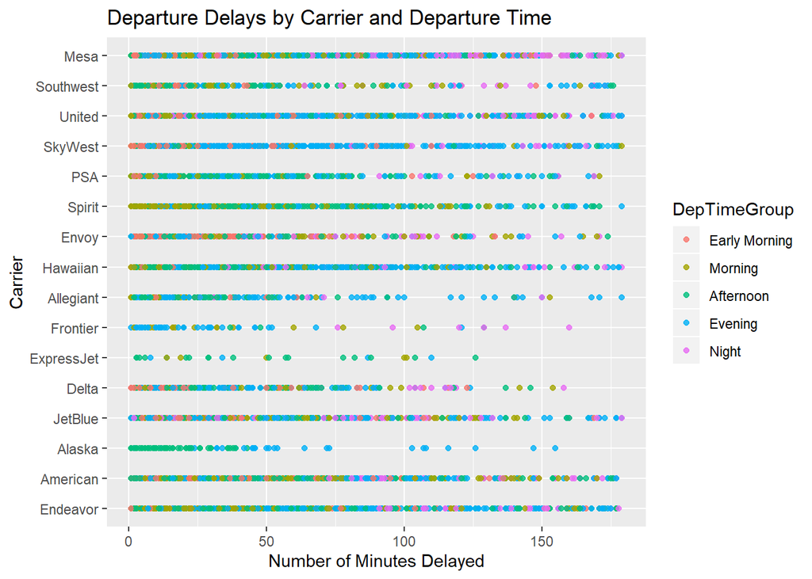

```r
ggplot(data=less120d, aes(x=DepDelayNew, y=Carrier, color=DepTimeGroup)) + geom_point(alpha=0.8) + labs(x="Number of Minutes Delayed", fill="Scheduled Departure Time", title="Departure Delays by Carrier and Departure Time")
```

**Interpretation:**

A general trend that can be seen in this data is that early morning flights (orange colors) tend to appear more on the left of the scatterplot (when delay time is low), afternoon and evening flights (green and blue) tend to appear more in the middle of each scatter plot, and night and late nigt flights (purple and pink) tend to appear furthest to the right of each scatter plot. This means that it seems that as the departure or arrival time is scheduled later and later in the day, the delays also seem to become longer and longer in general.

Let’s see if there is another good way to visualize this trend.

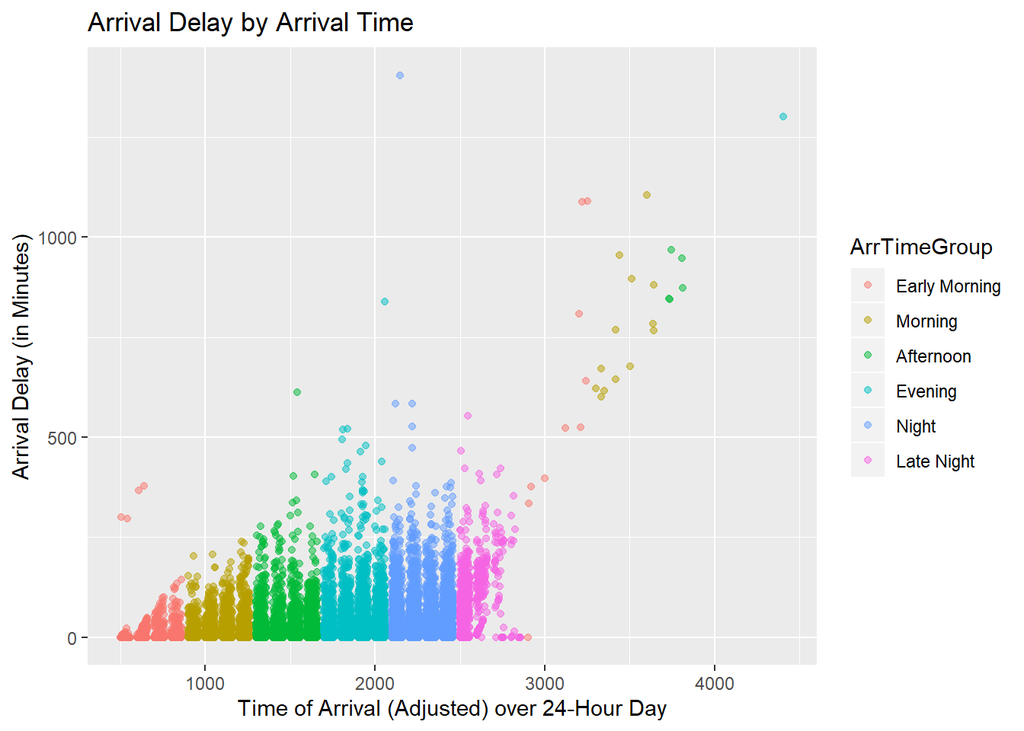

```r
ggplot(data=PIT_2019_ArrivePit.df, aes(x=AdjArrTime, y=ArrDelayNew, color=ArrTimeGroup)) + geom_point(alpha=0.5) +labs(x="Time of Arrival (Adjusted) over 24-Hour Day",y="Arrival Delay (in Minutes)", title="Arrival Delay by Arrival Time")
```

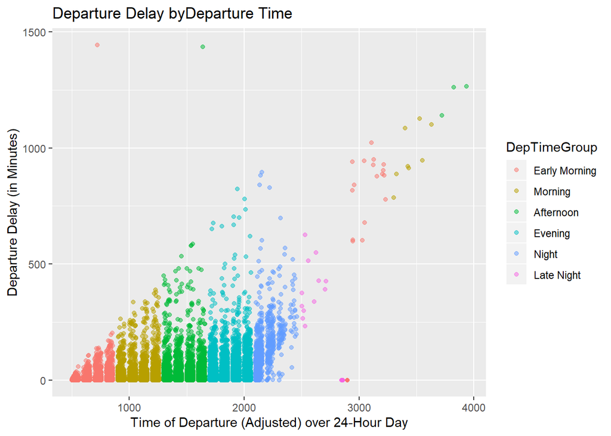

```r
ggplot(data=PIT_2019_DepartPit.df, aes(x=AdjDepTime, y=DepDelayNew, color=DepTimeGroup)) + geom_point(alpha=0.5) +labs(x="Time of Departure (Adjusted) over 24-Hour Day",y="Departure Delay (in Minutes)", title="Departure Delay byDeparture Time")
```

**Interpretation:**

What both of these scatterplots illustrate is that, in general, as time moves from morning to afternoon to night, delays get longer. Flights scheduled for the early morning have shorter delays than those scheduled later in the day. Though most of the data falls within a 24-hour, the data was adjusted to account for delays that caused the flight to be pushed to the next day. Any flights that were pushed to the next day received an Arrival or Departure time of 24 hours + the new arrival or departure time. Furthermore, the 24-hour day is shown as starting at 5am here (or 500 on the x-axis). Therefore, flights that are shown to the right of 2900 on the x-axis (500 + 2400), were flights that were delayed to the next day.

#### Heatmaps

We also explored a number of heatmaps to try to identify relationships between categorical variables. These heatmaps are shown below.

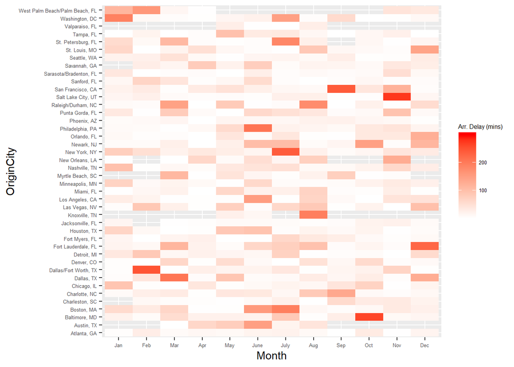

```r
arr1 <- subset(PIT_2019_ArrivePit.df, ArrDelayNew > 0 & ArrDelayNew <300 )
ggplot(arr1, aes(x=Month, y=OriginCity, fill=ArrDelayNew)) + geom_tile() + scale_fill_gradient(low="white", high="red") +labs(fill="Arr. Delay (mins)") + theme(legend.title=element_text(size=6), legend.text = element_text(size=5), axis.text.x=element_text(size=5), axis.text.y=element_text(size=5))
```

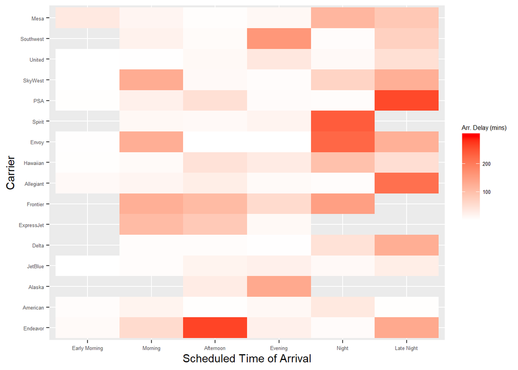

```r
ggplot(arr1, aes(x=ArrTimeGroup, y=Carrier, fill=ArrDelayNew)) + geom_tile() + scale_fill_gradient(low="white", high="red") +labs(x="Scheduled Time of Arrival", fill= "Arr. Delay (mins)") + theme(legend.title=element_text(size=6), legend.text = element_text(size=5), axis.text.x=element_text(size=5), axis.text.y=element_text(size=5))
```

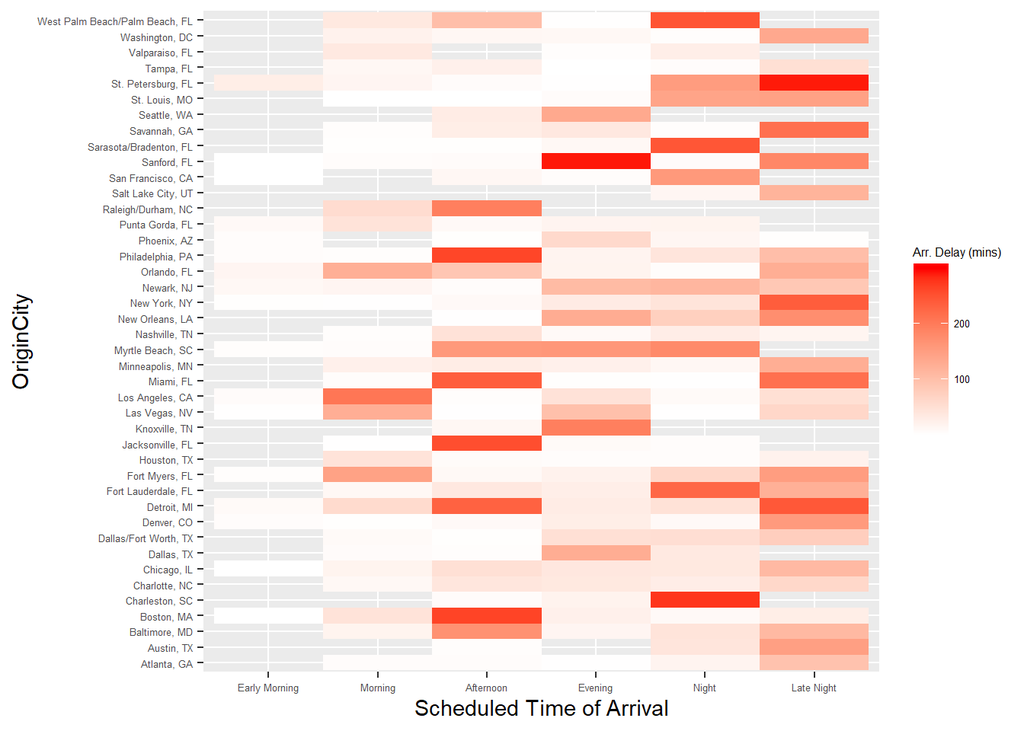

```r
ggplot(arr1, aes(x=ArrTimeGroup, y=OriginCity, fill=ArrDelayNew)) + geom_tile() + scale_fill_gradient(low="white", high="red") +labs(x="Scheduled Time of Arrival", fill= "Arr. Delay (mins)") + theme(legend.title=element_text(size=6), legend.text = element_text(size=5), axis.text.x=element_text(size=5), axis.text.y=element_text(size=5))
```

**Interpretation:**

These heatmaps can help us to identify where interactions between categorical variables may be signficant. The spots on the heatmap that are brightest red indicate combinations of categorical variables that produced longer delays in arrival and departure compared to combinations producing lighter pink or white colors.

**Findings from Exploratory Data Analysis:** There seem to be a number of variables that correlate to flight delays. The variables that we have seen differences for include Carrier and Arrival Time and Departure time (when adjusted for carrying over to the next day.) Likewise, there seem to be some interactions between categorical variables which cause certain combinations of features to yield longer delays. We will try to accomodate these findings in our models moving forward.

## 4. Fitting our Models

We will use linear regression (and glm) as well as a regression tree with bagging and boosting.

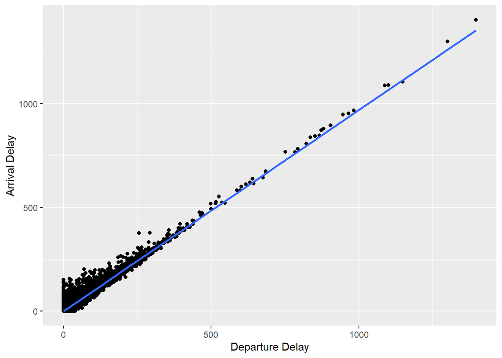

```r
# Regression plot for Arrival Delay and Departure delay

qplot(data = PIT_2019_ArrivePit.df, x = DepDelayNew, y = ArrDelayNew,
      xlab = "Departure Delay", ylab = "Arrival Delay") + stat_smooth(method = "lm")
```

**Relationship between Arrival and Departure delay:**

As discussed in earlier sections, the Arrival and Departure delay are highly correlated. So we do not include departure delay while regressing for the arrival delay and vice versa.

```r
# Define train and test set
set.seed(4)
train <- sample(1:nrow(PIT_2019_ArrivePit.df), nrow(PIT_2019_ArrivePit.df)/2)
test <- PIT_2019_ArrivePit.df$ArrDelayNew[-train]
```

```r
#Multiple Linear Regression

#Arrival delay - with all delays
lm.fit.arrdelay.1 <-lm(ArrDelayNew ~ Month+ DayOfMonth + DayOfWeek + Carrier + OriginCity + DepDelayNew +Distance + AdjArrTime + CarrierDelay + WeatherDelay + NasDelay + SecurityDelay + LateAircraftDelay, data = PIT_2019_ArrivePit.df, subset = train)
#summary(lm.fit.arrdelay.1)
#summary(lm.fit.arrdelay.1)$r.sq

#Arrival delay - with all delays other than DepDelayNew
lm.fit.arrdelay.2 <-lm(ArrDelayNew ~ Month+ DayOfMonth + DayOfWeek + Carrier + OriginCity +Distance + AdjArrTime + CarrierDelay + WeatherDelay + NasDelay + SecurityDelay + LateAircraftDelay, data = PIT_2019_ArrivePit.df, subset = train)
#summary(lm.fit.arrdelay.2)
#summary(lm.fit.arrdelay.2)$r.sq

#Arrival delay - with only DepDelayNew
lm.fit.arrdelay.3 <-lm(ArrDelayNew ~ Month+ DayOfMonth + DayOfWeek + Carrier + OriginCity + DepDelayNew +Distance + AdjArrTime, data = PIT_2019_ArrivePit.df, subset = train)
#summary(lm.fit.arrdelay.3)
#summary(lm.fit.arrdelay.3)$r.sq

#Arrival delay - without other delay variables

lm.fit.arrdelay.4 <- lm(ArrDelayNew ~ Month + DayOfMonth + DayOfWeek + Carrier + OriginCity + AdjArrTime + Distance ,data = PIT_2019_ArrivePit.df, subset = train)
summary(lm.fit.arrdelay.4)
```

```
##
## Call:
## lm(formula = ArrDelayNew ~ Month + DayOfMonth + DayOfWeek + Carrier +
##     OriginCity + AdjArrTime + Distance, data = PIT_2019_ArrivePit.df,
##     subset = train)
##
## Residuals:
##    Min     1Q Median     3Q    Max
## -50.11 -16.20  -6.81   3.15 899.19
##
## Coefficients: (1 not defined because of singularities)
##                                              Estimate   Std. Error t value
## (Intercept)                               -46.2424735   48.5142760  -0.953
## MonthFeb                                   -2.1831467    1.2032741  -1.814
## MonthMar                                   -4.5049202    1.1423160  -3.944
## MonthApr                                   -2.3445731    1.1522627  -2.035
## MonthMay                                   -0.5242243    1.1375494  -0.461
## MonthJune                                   5.9288483    1.1477503   5.166
## MonthJuly                                   2.8493294    1.1439565   2.491
## MonthAug                                    1.0221537    1.1363664   0.899
## MonthSep                                   -5.5536788    1.1508977  -4.826
## MonthOct                                   -4.7376377    1.1357889  -4.171
## MonthNov                                   -6.7062227    1.1421867  -5.871
## MonthDec                                    1.2112836    1.1576337   1.046
## DayOfMonth2                                -2.1355134    1.7986939  -1.187
## DayOfMonth3                               -10.5530869    1.7879653  -5.902
## DayOfMonth4                               -11.7524829    1.7939322  -6.551
## DayOfMonth5                               -11.6103484    1.8081109  -6.421
## DayOfMonth6                                -9.1896397    1.7940979  -5.122
## DayOfMonth7                                -9.9416361    1.7768814  -5.595
## DayOfMonth8                                -6.7155034    1.7626977  -3.810
## DayOfMonth9                                -7.6299390    1.7933305  -4.255
## DayOfMonth10                               -6.9371614    1.7653370  -3.930
## DayOfMonth11                               -5.1697066    1.7877235  -2.892
## DayOfMonth12                               -9.6271715    1.7824296  -5.401
## DayOfMonth13                               -7.8169068    1.7930321  -4.360
## DayOfMonth14                               -9.3723037    1.7801219  -5.265
## DayOfMonth15                              -10.1961874    1.7604495  -5.792
## DayOfMonth16                              -11.3218887    1.7606856  -6.430
## DayOfMonth17                               -6.5739493    1.7859591  -3.681
```

[output cut: 176 more lines]

```
## OriginCitySeattle, WA                          NA
## OriginCitySt. Louis, MO                  0.067401 .
## OriginCitySt. Petersburg, FL             0.713450
## OriginCityTampa, FL                      0.394656
## OriginCityValparaiso, FL                 0.382890
## OriginCityWashington, DC                 0.392689
## OriginCityWest Palm Beach/Palm Beach, FL 0.710202
## AdjArrTime                                < 2e-16 ***
## Distance                                 0.451831
## ---
## Signif. codes:  0 '***' 0.001 '**' 0.01 '*' 0.05 '.' 0.1 ' ' 1
##
## Residual standard error: 36.23 on 24607 degrees of freedom
## Multiple R-squared:  0.09213,    Adjusted R-squared:  0.08829
## F-statistic: 24.01 on 104 and 24607 DF,  p-value: < 2.2e-16
```

```r
#summary(lm.fit.arrdelay.4)$r.sq

#Arrival delay - without other delay variables, interaction terms for Carrier and OriginCity
lm.fit.arrdelay.5 <- lm(ArrDelayNew ~ Month + DayOfMonth + DayOfWeek + Carrier + OriginCity + AdjArrTime + Distance + Carrier*OriginCity,data = PIT_2019_ArrivePit.df, subset = train)
#summary(lm.fit.arrdelay.5)
#summary(lm.fit.arrdelay.5)$r.sq

#Arrival delay - without other delay variables, interaction terms for Month and DayOfMonth
lm.fit.arrdelay.6 <- lm(ArrDelayNew ~ Month + DayOfMonth + DayOfWeek + Carrier + OriginCity + AdjArrTime + Distance + Month*DayOfMonth,data = PIT_2019_ArrivePit.df, subset = train)
#summary(lm.fit.arrdelay.6)
#summary(lm.fit.arrdelay.6)$r.sq

#Arrival delay - without other delay variables, interaction terms for Carrier and OriginCity, Month and DayOfMonth
lm.fit.arrdelay.7 <- lm(ArrDelayNew ~ Month + DayOfMonth + DayOfWeek + Carrier + OriginCity + AdjArrTime + Distance + Carrier*OriginCity + Month*DayOfMonth,data = PIT_2019_ArrivePit.df, subset = train)
#summary(lm.fit.arrdelay.7)
#summary(lm.fit.arrdelay.7)$r.sq

#Departure delay
lm.fit.depdelay.1 <- lm(DepDelayNew ~ Month + DayOfMonth + DayOfWeek + Carrier + DestCity + AdjDepTime + Distance ,data = PIT_2019_DepartPit.df)
#summary(lm.fit.depdelay.1)
#summary(lm.fit.depdelay.1)$r.sq
```

**Interpretation of Regressions**:

The R2 values for Model with different set of independent variable are

1. All the associated delays are included along with other variables. R square value = 1
2. All delays other than Departure delay is included along with other variables. R square value = 1
3. Only Departure delay is included along with other variables. R square value = 0.9449184
4. Other variables with none of the associated delays are included. R square value = 0.0921298
5. Other variables with interaction term for City and Carrier are included. R square value =0.099076
6. Other variables with interaction term for DayofMonth and Month are included. R square value =0.1277844

From the above R square values, we can observe that the for predicting Arrival delay, the associated delay like departure delay, Security delay and weather delay provide more than 90% R-squared (even 99%). But these variables are highly correlated and add up to the arrival delay. Hence they are not better predictor. When use the other variables as in option 4, the R-squared value is below 10%. Adding the interaction terms increases R-squared slighly and explain the model better. So a model like regression trees could give between prediction as they take into account the interactions. We will now use subset selection methods to find the best set of variables to use. using the other associated delays for model selection will lead us to select just these variables alone. So the other associated delays are not going to be included for our model selection process.

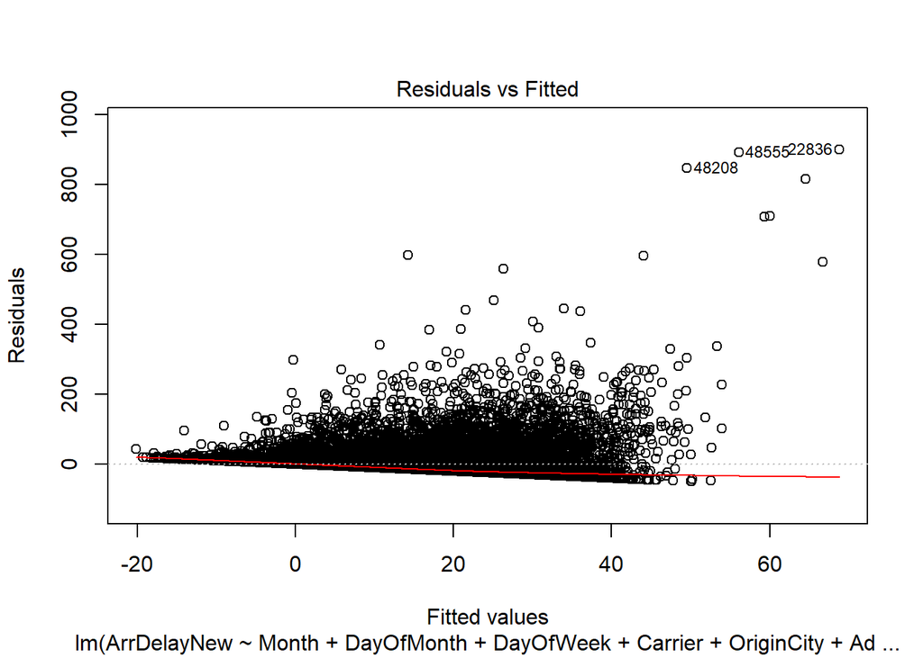

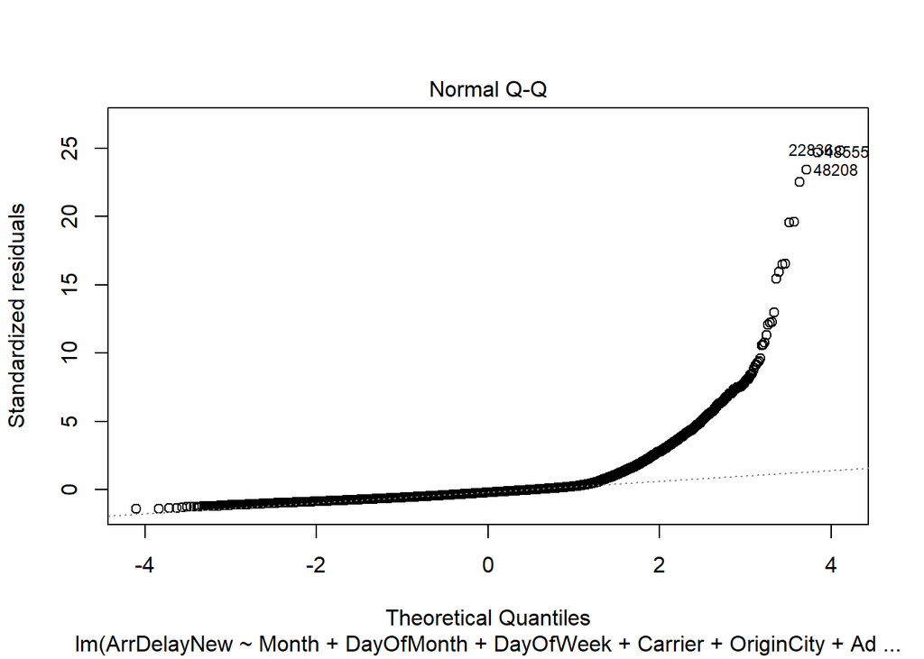

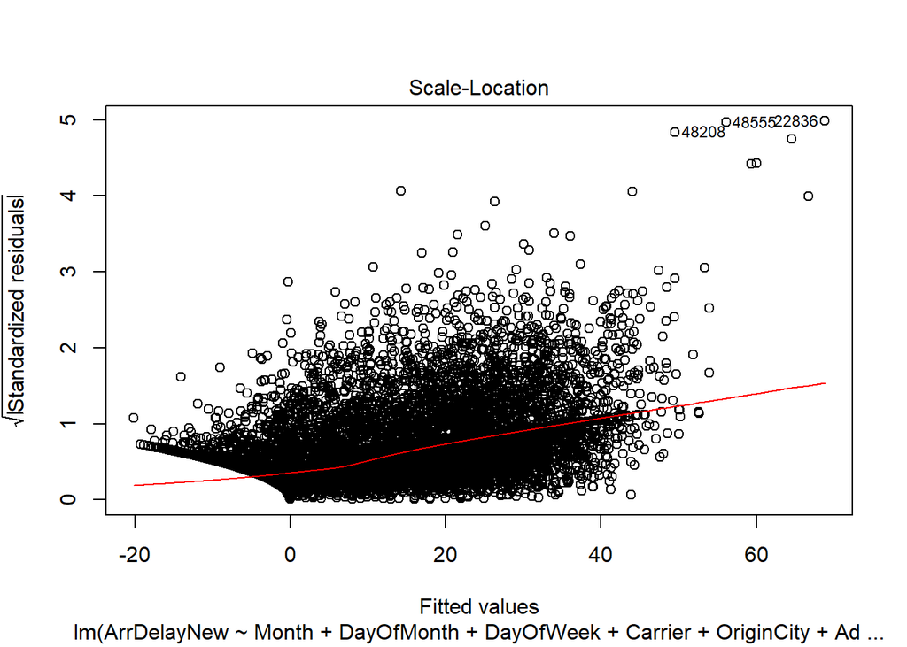

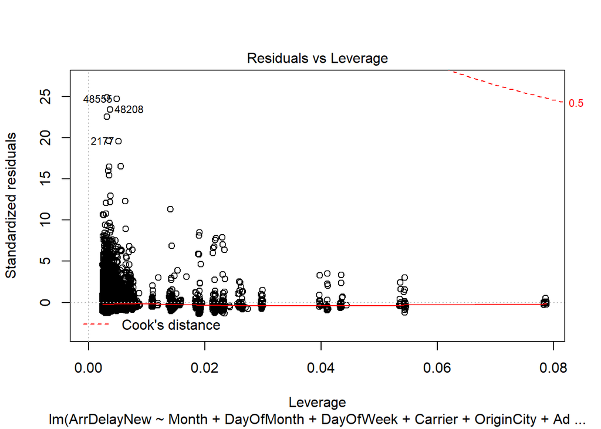

```r
#Diagnostic plots

plot(lm.fit.arrdelay.4)
```

**Residual plots**

The inconsistencies in the residual plots show that regression may not be the best model for this case in predicting the outcomes.

**Model Selection**

```r
# Forward Stepwise selection
regfit.fwd=regsubsets(ArrDelayNew∼ Month + DayOfMonth + DayOfWeek + Carrier + OriginCity + AdjArrTime + Distance ,data = PIT_2019_ArrivePit.df ,nvmax =7,method ="forward", subset=train)
```

```
## Reordering variables and trying again:
```

```r
reg.summary.fwd =summary (regfit.fwd)
reg.summary.fwd$rsq
```

```
## [1] 0.05624839 0.06004720 0.06313149 0.06607024 0.06748619 0.06886069
## [7] 0.06999175 0.07105701
```

```r
par(mfrow =c(2,2))
plot(reg.summary.fwd$rss ,xlab=" Number of Variables ",ylab=" RSS",type="l")
plot(reg.summary.fwd$adjr2 ,xlab =" Number of Variables ", ylab=" Adjusted RSq",type="l")


# Backward Stepwise selection
regfit.bwd=regsubsets(ArrDelayNew∼ Month + DayOfMonth + DayOfWeek + Carrier + OriginCity + AdjArrTime + Distance ,data = PIT_2019_ArrivePit.df ,nvmax =7,method ="backward", subset=train)
```

```
## Reordering variables and trying again:
```

```r
reg.summary.bwd =summary (regfit.bwd)
reg.summary.bwd$rsq
```

```
## [1] 0.05624839 0.06004720 0.06313149 0.06532736 0.06679874 0.06817403
## [7] 0.06976514 0.07120852
```

[figure not shown]

```r
par(mfrow =c(2,2))
```

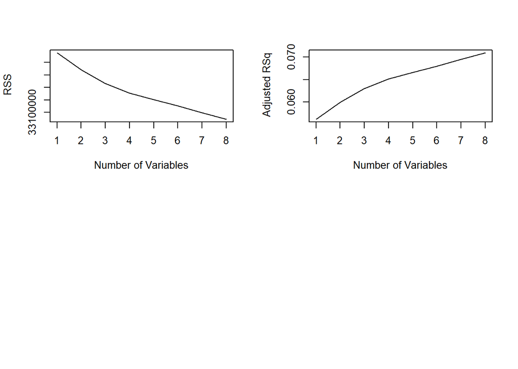

```r
plot(reg.summary.bwd$rss ,xlab=" Number of Variables ",ylab=" RSS",type="l")
plot(reg.summary.bwd$adjr2 ,xlab =" Number of Variables ", ylab=" Adjusted RSq",type="l")
```

**Interpretation:**

It can be observed with both Forward and Backward selection, the Adjusted R square is increasing for adding each variable and hence all the variables are going to be used for the linear regression model.

```r
predict.regsubsets =function (object ,newdata ,id ,...){
  form=as.formula (object$call [[2]])
  mat=model.matrix (form ,newdata )
  coefi =coef(object ,id=id)
  xvars =names (coefi )
  mat[,xvars ]%*% coefi
}

k=10
set.seed (1)
folds=sample (1:k,nrow(PIT_2019_ArrivePit.df),replace =TRUE)
cv.errors =matrix (NA ,k,7, dimnames =list(NULL , paste (1:7) ))

for(j in 1:k){
  best.fit =regsubsets (ArrDelayNew∼Month + DayOfMonth + DayOfWeek + Carrier + OriginCity + AdjArrTime + Distance,data=PIT_2019_ArrivePit.df [folds !=j,],nvmax =7,method ="forward", subset=train)
  for(i in 1:7) {
  pred=predict (best.fit ,PIT_2019_ArrivePit.df [folds ==j,], id=i)
  cv.errors [j,i]=mean( (PIT_2019_ArrivePit.df$ArrDelayNew[folds ==j]-pred)^2)
}
}
```

```
## Reordering variables and trying again:
## Reordering variables and trying again:
## Reordering variables and trying again:
## Reordering variables and trying again:
## Reordering variables and trying again:
## Reordering variables and trying again:
## Reordering variables and trying again:
## Reordering variables and trying again:
## Reordering variables and trying again:
## Reordering variables and trying again:
```